| title: “Data mining using Wisconsin breast cancer dataset” |
| --- |
| author: “Mehdi Rahmouni” |
| date: “January 23, 2017” |
| output: |
| html_document: default |

# Load ProjectTemplate() library

First we need to load the project which will automatically load the dataset.

```r
library('ProjectTemplate')
load.project()
```

```r
setwd("C://Users/Dell/Desktop/Dat640/Project/cancer/data")
```

Load libraries

use the variable wbcd to manipulate the dataset

```r
wbcd <- read.csv("C://Users/Dell/Desktop/Dat640/Project/cancer/data/breast_cancer_wisconsin.csv",
                 header = TRUE)
```

# Data exploration

check the dataset structure, variables types

```r
str(wbcd)
```

```
## 'data.frame':    569 obs. of  33 variables:
##  $ id                     : int  842302 842517 84300903 84348301 84358402 843786 844359 84458202 844981 84501001 ...
##  $ diagnosis              : Factor w/ 2 levels "B","M": 2 2 2 2 2 2 2 2 2 2 ...
##  $ radius_mean            : num  18 20.6 19.7 11.4 20.3 ...
##  $ texture_mean           : num  10.4 17.8 21.2 20.4 14.3 ...
##  $ perimeter_mean         : num  122.8 132.9 130 77.6 135.1 ...
##  $ area_mean              : num  1001 1326 1203 386 1297 ...
##  $ smoothness_mean        : num  0.1184 0.0847 0.1096 0.1425 0.1003 ...
##  $ compactness_mean       : num  0.2776 0.0786 0.1599 0.2839 0.1328 ...
##  $ concavity_mean         : num  0.3001 0.0869 0.1974 0.2414 0.198 ...
##  $ concave.points_mean    : num  0.1471 0.0702 0.1279 0.1052 0.1043 ...
##  $ symmetry_mean          : num  0.242 0.181 0.207 0.26 0.181 ...
##  $ fractal_dimension_mean : num  0.0787 0.0567 0.06 0.0974 0.0588 ...
##  $ radius_se              : num  1.095 0.543 0.746 0.496 0.757 ...
##  $ texture_se             : num  0.905 0.734 0.787 1.156 0.781 ...
```

[output cut: 19 more lines]

find column names

```r
names(wbcd)
```

```
##  [1] "id"                      "diagnosis"
##  [3] "radius_mean"             "texture_mean"
##  [5] "perimeter_mean"          "area_mean"
##  [7] "smoothness_mean"         "compactness_mean"
##  [9] "concavity_mean"          "concave.points_mean"
## [11] "symmetry_mean"           "fractal_dimension_mean"
## [13] "radius_se"               "texture_se"
## [15] "perimeter_se"            "area_se"
## [17] "smoothness_se"           "compactness_se"
## [19] "concavity_se"            "concave.points_se"
## [21] "symmetry_se"             "fractal_dimension_se"
## [23] "radius_worst"            "texture_worst"
## [25] "perimeter_worst"         "area_worst"
## [27] "smoothness_worst"        "compactness_worst"
## [29] "concavity_worst"         "concave.points_worst"
## [31] "symmetry_worst"          "fractal_dimension_worst"
## [33] "X"
```

dataset number of rows

```r
nrow(wbcd)
```

```
## [1] 569
```

dataset number of columns

```r
ncol(wbcd)
```

```
## [1] 33
```

top six rows

```r
head((wbcd),6)
```

```
##         id diagnosis radius_mean texture_mean perimeter_mean area_mean
## 1   842302         M       17.99        10.38         122.80    1001.0
## 2   842517         M       20.57        17.77         132.90    1326.0
## 3 84300903         M       19.69        21.25         130.00    1203.0
## 4 84348301         M       11.42        20.38          77.58     386.1
## 5 84358402         M       20.29        14.34         135.10    1297.0
## 6   843786         M       12.45        15.70          82.57     477.1
##   smoothness_mean compactness_mean concavity_mean concave.points_mean
## 1         0.11840          0.27760         0.3001             0.14710
## 2         0.08474          0.07864         0.0869             0.07017
## 3         0.10960          0.15990         0.1974             0.12790
## 4         0.14250          0.28390         0.2414             0.10520
## 5         0.10030          0.13280         0.1980             0.10430
## 6         0.12780          0.17000         0.1578             0.08089
##   symmetry_mean fractal_dimension_mean radius_se texture_se perimeter_se
```

[output cut: 41 more lines]

last six rows

```r
tail((wbcd),6)
```

```
##         id diagnosis radius_mean texture_mean perimeter_mean area_mean
## 564 926125         M       20.92        25.09         143.00    1347.0
## 565 926424         M       21.56        22.39         142.00    1479.0
## 566 926682         M       20.13        28.25         131.20    1261.0
## 567 926954         M       16.60        28.08         108.30     858.1
## 568 927241         M       20.60        29.33         140.10    1265.0
## 569  92751         B        7.76        24.54          47.92     181.0
##     smoothness_mean compactness_mean concavity_mean concave.points_mean
## 564         0.10990          0.22360        0.31740             0.14740
## 565         0.11100          0.11590        0.24390             0.13890
## 566         0.09780          0.10340        0.14400             0.09791
## 567         0.08455          0.10230        0.09251             0.05302
## 568         0.11780          0.27700        0.35140             0.15200
## 569         0.05263          0.04362        0.00000             0.00000
##     symmetry_mean fractal_dimension_mean radius_se texture_se perimeter_se
```

[output cut: 41 more lines]

outcome distribution

```r
table(wbcd$diagnosis)
```

```
##
##   B   M
## 357 212
```

# Exploratory data analysis

number of rows and columns

```r
dim(wbcd)
```

```
## [1] 569  33
```

6 number summary

```r
summary(wbcd)
```

```
##        id            diagnosis  radius_mean      texture_mean
##  Min.   :     8670   B:357     Min.   : 6.981   Min.   : 9.71
##  1st Qu.:   869218   M:212     1st Qu.:11.700   1st Qu.:16.17
##  Median :   906024             Median :13.370   Median :18.84
##  Mean   : 30371831             Mean   :14.127   Mean   :19.29
##  3rd Qu.:  8813129             3rd Qu.:15.780   3rd Qu.:21.80
##  Max.   :911320502             Max.   :28.110   Max.   :39.28
##  perimeter_mean     area_mean      smoothness_mean   compactness_mean
##  Min.   : 43.79   Min.   : 143.5   Min.   :0.05263   Min.   :0.01938
##  1st Qu.: 75.17   1st Qu.: 420.3   1st Qu.:0.08637   1st Qu.:0.06492
##  Median : 86.24   Median : 551.1   Median :0.09587   Median :0.09263
##  Mean   : 91.97   Mean   : 654.9   Mean   :0.09636   Mean   :0.10434
##  3rd Qu.:104.10   3rd Qu.: 782.7   3rd Qu.:0.10530   3rd Qu.:0.13040
##  Max.   :188.50   Max.   :2501.0   Max.   :0.16340   Max.   :0.34540
##  concavity_mean    concave.points_mean symmetry_mean
##  Min.   :0.00000   Min.   :0.00000     Min.   :0.1060
##  1st Qu.:0.02956   1st Qu.:0.02031     1st Qu.:0.1619
##  Median :0.06154   Median :0.03350     Median :0.1792
##  Mean   :0.08880   Mean   :0.04892     Mean   :0.1812
##  3rd Qu.:0.13070   3rd Qu.:0.07400     3rd Qu.:0.1957
##  Max.   :0.42680   Max.   :0.20120     Max.   :0.3040
##  fractal_dimension_mean   radius_se        texture_se      perimeter_se
##  Min.   :0.04996        Min.   :0.1115   Min.   :0.3602   Min.   : 0.757
##  1st Qu.:0.05770        1st Qu.:0.2324   1st Qu.:0.8339   1st Qu.: 1.606
##  Median :0.06154        Median :0.3242   Median :1.1080   Median : 2.287
##  Mean   :0.06280        Mean   :0.4052   Mean   :1.2169   Mean   : 2.866
##  3rd Qu.:0.06612        3rd Qu.:0.4789   3rd Qu.:1.4740   3rd Qu.: 3.357
##  Max.   :0.09744        Max.   :2.8730   Max.   :4.8850   Max.   :21.980
##     area_se        smoothness_se      compactness_se      concavity_se
##  Min.   :  6.802   Min.   :0.001713   Min.   :0.002252   Min.   :0.00000
##  1st Qu.: 17.850   1st Qu.:0.005169   1st Qu.:0.013080   1st Qu.:0.01509
##  Median : 24.530   Median :0.006380   Median :0.020450   Median :0.02589
##  Mean   : 40.337   Mean   :0.007041   Mean   :0.025478   Mean   :0.03189
##  3rd Qu.: 45.190   3rd Qu.:0.008146   3rd Qu.:0.032450   3rd Qu.:0.04205
##  Max.   :542.200   Max.   :0.031130   Max.   :0.135400   Max.   :0.39600
##  concave.points_se   symmetry_se       fractal_dimension_se
##  Min.   :0.000000   Min.   :0.007882   Min.   :0.0008948
##  1st Qu.:0.007638   1st Qu.:0.015160   1st Qu.:0.0022480
##  Median :0.010930   Median :0.018730   Median :0.0031870
##  Mean   :0.011796   Mean   :0.020542   Mean   :0.0037949
```

[output cut: 8 more lines]

```
##  Max.   :36.04   Max.   :49.54   Max.   :251.20   Max.   :4254.0
##  smoothness_worst  compactness_worst concavity_worst  concave.points_worst
##  Min.   :0.07117   Min.   :0.02729   Min.   :0.0000   Min.   :0.00000
##  1st Qu.:0.11660   1st Qu.:0.14720   1st Qu.:0.1145   1st Qu.:0.06493
##  Median :0.13130   Median :0.21190   Median :0.2267   Median :0.09993
##  Mean   :0.13237   Mean   :0.25427   Mean   :0.2722   Mean   :0.11461
##  3rd Qu.:0.14600   3rd Qu.:0.33910   3rd Qu.:0.3829   3rd Qu.:0.16140
##  Max.   :0.22260   Max.   :1.05800   Max.   :1.2520   Max.   :0.29100
##  symmetry_worst   fractal_dimension_worst    X
##  Min.   :0.1565   Min.   :0.05504         Mode:logical
##  1st Qu.:0.2504   1st Qu.:0.07146         NA's:569
##  Median :0.2822   Median :0.08004
##  Mean   :0.2901   Mean   :0.08395
##  3rd Qu.:0.3179   3rd Qu.:0.09208
##  Max.   :0.6638   Max.   :0.20750
```

find which column contains missing values

```r
colnames(wbcd)[colSums(is.na(wbcd)) > 0]
```

```
## [1] "X"
```

skewness

```r
sapply(wbcd,skewness)
```

```
##                      id               diagnosis             radius_mean
##               6.4396595                      NA               0.9374168
##            texture_mean          perimeter_mean               area_mean
##               0.6470241               0.9854334               1.6370654
##         smoothness_mean        compactness_mean          concavity_mean
##               0.4539207               1.1838556               1.3938008
##     concave.points_mean           symmetry_mean  fractal_dimension_mean
##               1.1650124               0.7217877               1.2976191
##               radius_se              texture_se            perimeter_se
##               3.0723468               1.6377733               3.4254803
##                 area_se           smoothness_se          compactness_se
##               5.4185001               2.3022616               1.8922032
##            concavity_se       concave.points_se             symmetry_se
##               5.0835502               1.4370701               2.1835728
##    fractal_dimension_se            radius_worst           texture_worst
##               3.9033041               1.0973059               0.4956970
##         perimeter_worst              area_worst        smoothness_worst
##               1.1222227               1.8495814               0.4132383
##       compactness_worst         concavity_worst    concave.points_worst
##               1.4657948               1.1441794               0.4900213
##          symmetry_worst fractal_dimension_worst                       X
##               1.4263764               1.6538237                      NA
```

kurtosis

```r
sapply(wbcd,kurtosis)
```

```
##                      id               diagnosis             radius_mean
##              41.6554369                      NA               0.8141418
##            texture_mean          perimeter_mean               area_mean
##               0.7280071               0.9392821               3.5865488
##         smoothness_mean        compactness_mean          concavity_mean
##               0.8244671               1.6088967               1.9531357
##     concave.points_mean           symmetry_mean  fractal_dimension_mean
##               1.0324689               1.2511350               2.9480546
##               radius_se              texture_se            perimeter_se
##              17.4490950               5.2626335              21.1187748
##                 area_se           smoothness_se          compactness_se
##              48.5853970              10.3205924               5.0226922
##            concavity_se       concave.points_se             symmetry_se
##              48.2419738               5.0424962               7.7784025
##    fractal_dimension_se            radius_worst           texture_worst
##              25.9379658               0.9115026               0.2005300
##         perimeter_worst              area_worst        smoothness_worst
##               1.0360188               4.3215281               0.4904586
##       compactness_worst         concavity_worst    concave.points_worst
##               2.9810417               1.5744467              -0.5500014
##          symmetry_worst fractal_dimension_worst                       X
##               4.3691029               5.1593559                      NA
```

data visualization using histogram plots

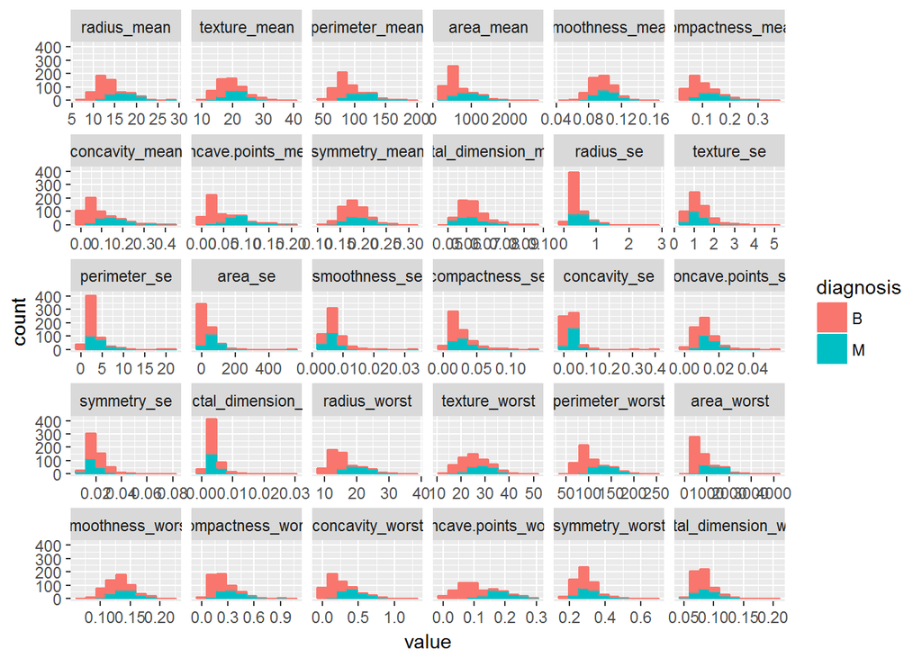

# Data transformation

load the dataset again, because after the plot we have a completly different dataset

```r
wbcd <- read.csv("C://Users/Dell/Desktop/Dat640/Project/cancer/data/breast_cancer_wisconsin.csv",
                 header = TRUE)
```

impute id, X

```r
wbcd$id <- NULL
wbcd$X <- NULL
```

assign Benign, Malignant to diagnosis and change type to factor

```r
wbcd$diagnosis <- factor(wbcd$diagnosis, levels = c("B", "M"),
                         labels = c("Benign", "Malignant"))
```

verify that id and X are gone

```r
str(wbcd)
```

```
## 'data.frame':    569 obs. of  31 variables:
##  $ diagnosis              : Factor w/ 2 levels "Benign","Malignant": 2 2 2 2 2 2 2 2 2 2 ...
##  $ radius_mean            : num  18 20.6 19.7 11.4 20.3 ...
##  $ texture_mean           : num  10.4 17.8 21.2 20.4 14.3 ...
##  $ perimeter_mean         : num  122.8 132.9 130 77.6 135.1 ...
##  $ area_mean              : num  1001 1326 1203 386 1297 ...
##  $ smoothness_mean        : num  0.1184 0.0847 0.1096 0.1425 0.1003 ...
##  $ compactness_mean       : num  0.2776 0.0786 0.1599 0.2839 0.1328 ...
##  $ concavity_mean         : num  0.3001 0.0869 0.1974 0.2414 0.198 ...
##  $ concave.points_mean    : num  0.1471 0.0702 0.1279 0.1052 0.1043 ...
##  $ symmetry_mean          : num  0.242 0.181 0.207 0.26 0.181 ...
##  $ fractal_dimension_mean : num  0.0787 0.0567 0.06 0.0974 0.0588 ...
##  $ radius_se              : num  1.095 0.543 0.746 0.496 0.757 ...
##  $ texture_se             : num  0.905 0.734 0.787 1.156 0.781 ...
##  $ perimeter_se           : num  8.59 3.4 4.58 3.44 5.44 ...
```

[output cut: 17 more lines]

check number of observations and percentage

```r
cbind(Frequency = table(wbcd$diagnosis), Percentage = (prop.table(table(wbcd$diagnosis))* 100))
```

```
##           Frequency Percentage
## Benign          357   62.74165
## Malignant       212   37.25835
```

data summary

```r
summary(wbcd)
```

```
##      diagnosis    radius_mean      texture_mean   perimeter_mean
##  Benign   :357   Min.   : 6.981   Min.   : 9.71   Min.   : 43.79
##  Malignant:212   1st Qu.:11.700   1st Qu.:16.17   1st Qu.: 75.17
##                  Median :13.370   Median :18.84   Median : 86.24
##                  Mean   :14.127   Mean   :19.29   Mean   : 91.97
##                  3rd Qu.:15.780   3rd Qu.:21.80   3rd Qu.:104.10
##                  Max.   :28.110   Max.   :39.28   Max.   :188.50
##    area_mean      smoothness_mean   compactness_mean  concavity_mean
##  Min.   : 143.5   Min.   :0.05263   Min.   :0.01938   Min.   :0.00000
##  1st Qu.: 420.3   1st Qu.:0.08637   1st Qu.:0.06492   1st Qu.:0.02956
##  Median : 551.1   Median :0.09587   Median :0.09263   Median :0.06154
##  Mean   : 654.9   Mean   :0.09636   Mean   :0.10434   Mean   :0.08880
##  3rd Qu.: 782.7   3rd Qu.:0.10530   3rd Qu.:0.13040   3rd Qu.:0.13070
##  Max.   :2501.0   Max.   :0.16340   Max.   :0.34540   Max.   :0.42680
##  concave.points_mean symmetry_mean    fractal_dimension_mean
##  Min.   :0.00000     Min.   :0.1060   Min.   :0.04996
##  1st Qu.:0.02031     1st Qu.:0.1619   1st Qu.:0.05770
##  Median :0.03350     Median :0.1792   Median :0.06154
##  Mean   :0.04892     Mean   :0.1812   Mean   :0.06280
##  3rd Qu.:0.07400     3rd Qu.:0.1957   3rd Qu.:0.06612
##  Max.   :0.20120     Max.   :0.3040   Max.   :0.09744
##    radius_se        texture_se      perimeter_se       area_se
##  Min.   :0.1115   Min.   :0.3602   Min.   : 0.757   Min.   :  6.802
##  1st Qu.:0.2324   1st Qu.:0.8339   1st Qu.: 1.606   1st Qu.: 17.850
##  Median :0.3242   Median :1.1080   Median : 2.287   Median : 24.530
##  Mean   :0.4052   Mean   :1.2169   Mean   : 2.866   Mean   : 40.337
##  3rd Qu.:0.4789   3rd Qu.:1.4740   3rd Qu.: 3.357   3rd Qu.: 45.190
##  Max.   :2.8730   Max.   :4.8850   Max.   :21.980   Max.   :542.200
##  smoothness_se      compactness_se      concavity_se
##  Min.   :0.001713   Min.   :0.002252   Min.   :0.00000
##  1st Qu.:0.005169   1st Qu.:0.013080   1st Qu.:0.01509
##  Median :0.006380   Median :0.020450   Median :0.02589
##  Mean   :0.007041   Mean   :0.025478   Mean   :0.03189
##  3rd Qu.:0.008146   3rd Qu.:0.032450   3rd Qu.:0.04205
##  Max.   :0.031130   Max.   :0.135400   Max.   :0.39600
##  concave.points_se   symmetry_se       fractal_dimension_se
##  Min.   :0.000000   Min.   :0.007882   Min.   :0.0008948
##  1st Qu.:0.007638   1st Qu.:0.015160   1st Qu.:0.0022480
##  Median :0.010930   Median :0.018730   Median :0.0031870
##  Mean   :0.011796   Mean   :0.020542   Mean   :0.0037949
```

[output cut: 8 more lines]

```
##  Max.   :36.04   Max.   :49.54   Max.   :251.20   Max.   :4254.0
##  smoothness_worst  compactness_worst concavity_worst  concave.points_worst
##  Min.   :0.07117   Min.   :0.02729   Min.   :0.0000   Min.   :0.00000
##  1st Qu.:0.11660   1st Qu.:0.14720   1st Qu.:0.1145   1st Qu.:0.06493
##  Median :0.13130   Median :0.21190   Median :0.2267   Median :0.09993
##  Mean   :0.13237   Mean   :0.25427   Mean   :0.2722   Mean   :0.11461
##  3rd Qu.:0.14600   3rd Qu.:0.33910   3rd Qu.:0.3829   3rd Qu.:0.16140
##  Max.   :0.22260   Max.   :1.05800   Max.   :1.2520   Max.   :0.29100
##  symmetry_worst   fractal_dimension_worst
##  Min.   :0.1565   Min.   :0.05504
##  1st Qu.:0.2504   1st Qu.:0.07146
##  Median :0.2822   Median :0.08004
##  Mean   :0.2901   Mean   :0.08395
##  3rd Qu.:0.3179   3rd Qu.:0.09208
##  Max.   :0.6638   Max.   :0.20750
```

# Model building

ensure reproducibility with set.seed()

```r
set.seed(1)
```

split the dataset into training/tersting (70% training, 30% testing)

```r
inTrain <- createDataPartition(wbcd$diagnosis, p=0.7, list=FALSE)
training <- wbcd[inTrain,]
testing <- wbcd[-inTrain,]
```

training/testing dimensions

```r
dim(training)
```

```
## [1] 399  31
```

```r
dim(testing)
```

```
## [1] 170  31
```

outcome distribution in the testing set

```r
table(testing$diagnosis)
```

```
##
##    Benign Malignant
##       107        63
```

build a random forest model using the caret package

```r
set.seed(1)
rf_model <- train(diagnosis ~ ., data=training, method="rf")
rf_model
```

```
## Random Forest
##
## 399 samples
##  30 predictor
##   2 classes: 'Benign', 'Malignant'
##
## No pre-processing
## Resampling: Bootstrapped (25 reps)
## Summary of sample sizes: 399, 399, 399, 399, 399, 399, ...
## Resampling results across tuning parameters:
##
##   mtry  Accuracy   Kappa
##    2    0.9587503  0.9116467
##   16    0.9565456  0.9072886
##   30    0.9492084  0.8917163
##
## Accuracy was used to select the optimal model using  the largest value.
## The final value used for the model was mtry = 2.
```

```r
rf_model$finalModel
```

```
##
## Call:
##  randomForest(x = x, y = y, mtry = param$mtry)
##                Type of random forest: classification
##                      Number of trees: 500
## No. of variables tried at each split: 2
##
##         OOB estimate of  error rate: 3.51%
## Confusion matrix:
##           Benign Malignant class.error
## Benign       245         5  0.02000000
## Malignant      9       140  0.06040268
```

performance on testing test

```r
pred_test <- predict(rf_model, testing)
confusionMatrix(pred_test, testing$diagnosis, positive = "Malignant")
```

```
## Confusion Matrix and Statistics
##
##            Reference
## Prediction  Benign Malignant
##   Benign       105         3
##   Malignant      2        60
##
##                Accuracy : 0.9706
##                  95% CI : (0.9327, 0.9904)
##     No Information Rate : 0.6294
##     P-Value [Acc > NIR] : <2e-16
##
##                   Kappa : 0.9367
##  Mcnemar's Test P-Value : 1
##
##             Sensitivity : 0.9524
##             Specificity : 0.9813
##          Pos Pred Value : 0.9677
##          Neg Pred Value : 0.9722
##              Prevalence : 0.3706
##          Detection Rate : 0.3529
##    Detection Prevalence : 0.3647
##       Balanced Accuracy : 0.9668
##
##        'Positive' Class : Malignant
##
```

# Model tuning

tune Rf model to find best mtry using cross-validation

```r
ctrl <- trainControl(method="repeatedcv", repeats=3)
grid <- expand.grid(mtry = c(1, 2, 3, 5, 7, 10, 15, 20, 30))
set.seed(1)
rf_tune_model <- train(diagnosis ~ ., data=training, method="rf", tuneGrid = grid, trControl = ctrl)
rf_tune_model
```

```
## Random Forest
##
## 399 samples
##  30 predictor
##   2 classes: 'Benign', 'Malignant'
##
## No pre-processing
## Resampling: Cross-Validated (10 fold, repeated 3 times)
## Summary of sample sizes: 359, 359, 359, 359, 359, 360, ...
## Resampling results across tuning parameters:
##
##   mtry  Accuracy   Kappa
##    1    0.9631624  0.9200616
##    2    0.9674145  0.9301857
##    3    0.9657265  0.9265386
##    5    0.9623504  0.9193462
##    7    0.9631838  0.9213735
##   10    0.9623504  0.9197459
##   15    0.9648718  0.9251167
##   20    0.9615385  0.9179088
##   30    0.9590385  0.9126818
##
## Accuracy was used to select the optimal model using  the largest value.
## The final value used for the model was mtry = 2.
```

```r
rf_tune_model$finalModel
```

```
##
## Call:
##  randomForest(x = x, y = y, mtry = param$mtry)
##                Type of random forest: classification
##                      Number of trees: 500
## No. of variables tried at each split: 2
##
##         OOB estimate of  error rate: 3.51%
## Confusion matrix:
##           Benign Malignant class.error
## Benign       244         6  0.02400000
## Malignant      8       141  0.05369128
```

plot the new (tuned) mtry value

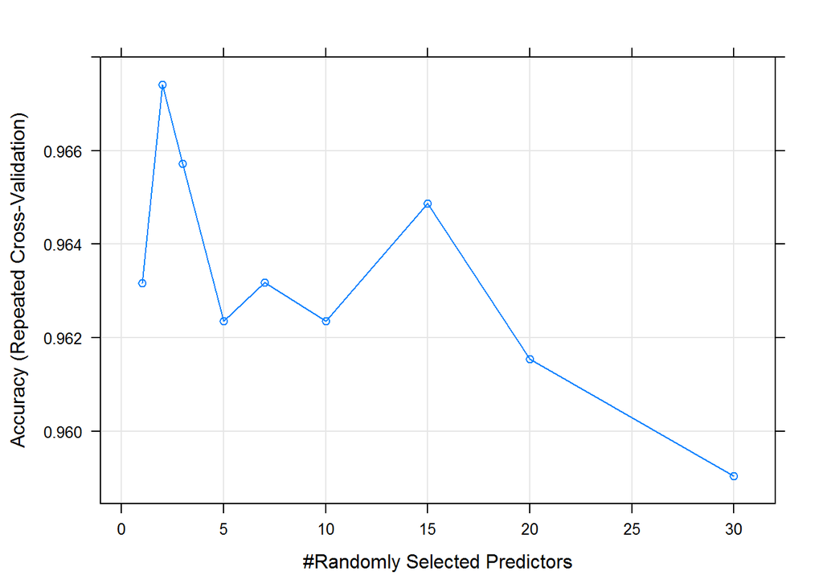

```r
plot(rf_tune_model)
```

performance of updated model on testing set

```r
pred_tuned_test <- predict(rf_tune_model, testing)
confusionMatrix(pred_tuned_test, testing$diagnosis, positive="Malignant")
```

```
## Confusion Matrix and Statistics
##
##            Reference
## Prediction  Benign Malignant
##   Benign       104         3
##   Malignant      3        60
##
##                Accuracy : 0.9647
##                  95% CI : (0.9248, 0.9869)
##     No Information Rate : 0.6294
##     P-Value [Acc > NIR] : <2e-16
##
##                   Kappa : 0.9243
##  Mcnemar's Test P-Value : 1
##
##             Sensitivity : 0.9524
##             Specificity : 0.9720
##          Pos Pred Value : 0.9524
##          Neg Pred Value : 0.9720
##              Prevalence : 0.3706
##          Detection Rate : 0.3529
##    Detection Prevalence : 0.3706
##       Balanced Accuracy : 0.9622
##
##        'Positive' Class : Malignant
##
```

# Other performance measures (Variable importance, ROC curve)

variable importance plot

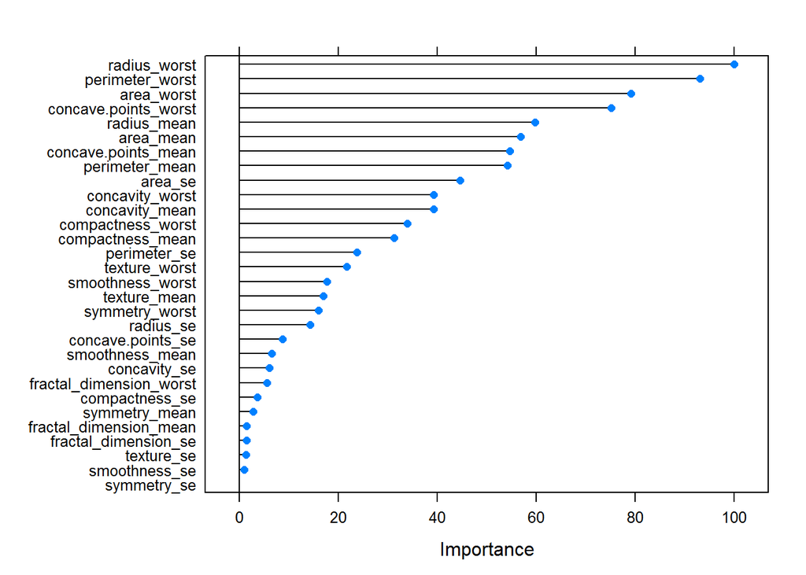

```r
rf_var <- varImp(rf_tune_model)
plot(rf_var)
```

ROC curve

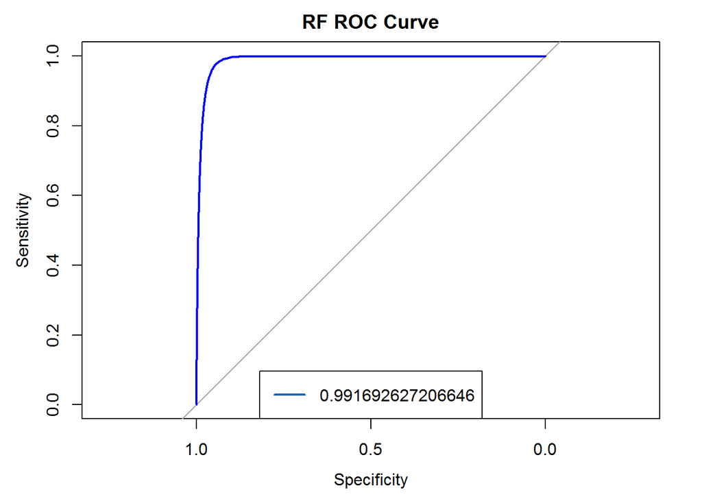

```r
rf_roc <- roc(testing$diagnosis,
              predict(rf_tune_model, testing, type = "prob")[,"Malignant"],
              levels = rev(levels(testing$diagnosis)))
roc_value <- auc(rf_roc)

plot.roc(smooth(rf_roc), main = "RF ROC Curve", col = "blue")
legend("bottom", legend = roc_value, col=c("#1c61b6"), lwd=2)
```